# Final_RDAVIS_SidneyWoodruff_updated

Sidney Woodruff

3/17/2020

## Initial Set-Up

Reading the files in.

```r
f <- read_csv("/Users/sidneywoodruff/Desktop/R_DAVIS_2020/R_DAVIS_in_class_project/data/raw_data/nyc_13_flights_new.csv")
p <- read_csv("/Users/sidneywoodruff/Desktop/R_DAVIS_2020/R_DAVIS_in_class_project/data/raw_data/nyc_13_planes.csv")
w <- read_csv("/Users/sidneywoodruff/Desktop/R_DAVIS_2020/R_DAVIS_in_class_project/data/raw_data/nyc_13_weather.csv")
```

I now need to join them together into one combined data table. I cannot join three tables at once, but I can join the planes table to the flights table, then join then weather table to the new combined planes and flights table.

**First**, I will join planes to flights by the column “tailnum.”  
**Next**, I will join weather to that new joined table by the origin, year, month, day, and hour.

```r
fp <- left_join(f, p, by = "tailnum")

colnames(fp)
names(fp)[names(fp) == "year.x"] <- "year"
names(fp)[names(fp) == "hour"] <- "hour_air"
names(fp)[names(fp) == "minute"] <- "minute_air"
# Needed to rename some columns so I can join with the weather data

fp$dep_time <- stringr::str_pad(fp$dep_time, 4, side = "left", pad = 0)
fp$sched_dep_time <- stringr::str_pad(fp$sched_dep_time, 4, side = "left", pad = 0)
fp$arr_time <- stringr::str_pad(fp$arr_time, 4, side = "left", pad = 0)
fp$sched_arr_time <- stringr::str_pad(fp$sched_arr_time, 4, side = "left", pad = 0)
# Adding zeroes to the front of the departure time and scheduled departure time data so that when we separate them, it will take the first two digits as hours and the last two digits as minutes. Went ahead and did this for arrival time and scheduled arrival time too, just in case we need it later set up like that to separate.


fp <- fp %>%
  separate(col = dep_time, c("hour", "min"), sep = 2)
# Now, the combined flights and planes data has columns to bind to with weather


# HOWEVER, we have to change the new hour and min columns from characters to numeric
fp$hour <- as.numeric(as.character(fp$hour))
fp$min <- as.numeric(as.character(fp$min))

fpw <- left_join(fp, w, by = c("origin", "year", "month", "day", "hour"))
```

Now, I have all of the three tables joined.

## ——-

### On to the actual assignment…

##### Question 1)

*Plot the departure delay of flights against the precipitation, and include a simple regression line as part of the plot. Hint: there is a geom_ that will plot a simple y ~ x regression line for you, but you might have to use an argument to make sure it’s a regular linear model.*

**View code here!**

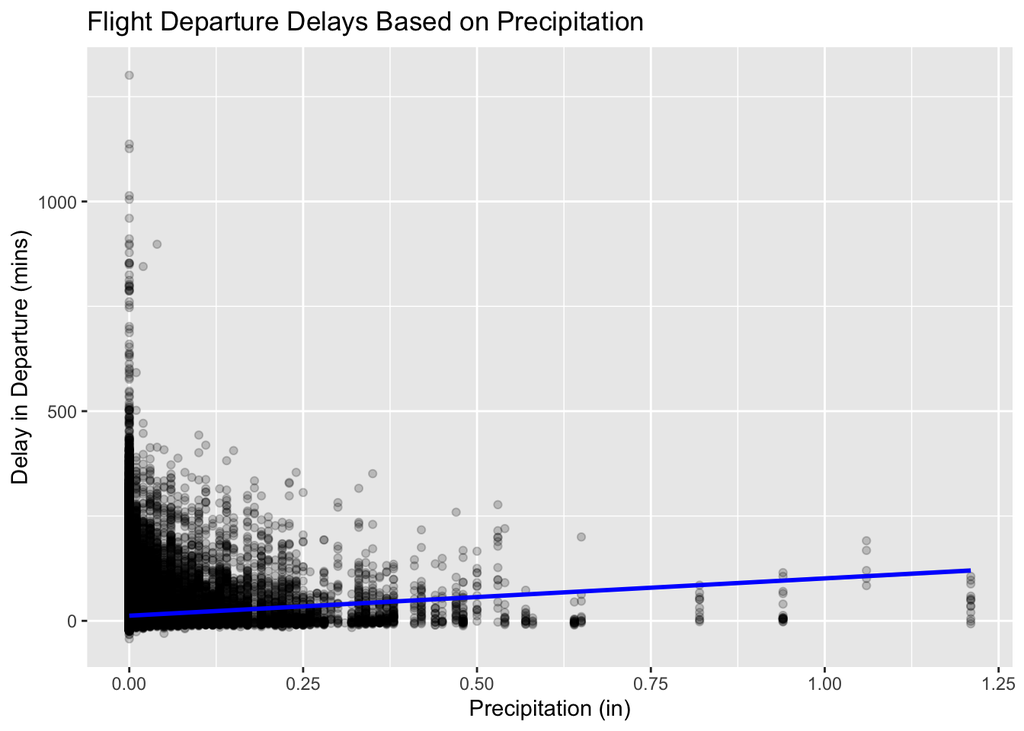

```r
q1 <- fpw %>%
  filter(!is.na(hour)) %>%
  filter(!is.na(precip)) %>%
  ggplot(mapping = aes(x = precip, y = dep_delay)) +
  geom_point(alpha = 0.2) +
  geom_smooth(method = lm, formula = y~x, color = "blue") +
  labs(x = "Precipitation (in)", y = "Delay in Departure (mins)", title = "Flight Departure Delays Based on Precipitation")
```